## Obserwacje po łącznej analizie rozkładu danych i macierzy korelacji

```r
library(htmlwidgets)
library(magrittr)
library(dygraphs)
library(webshot)
groupedData <- groupedData %>% mutate(mean_glony = mean(c(cfin1, cfin2, chel1, chel2, lcop1, lcop2)))
groupedData <- unfactor(groupedData)

make_sizes <- function(name){
  herr_vec <- groupedData[[name]]
  max <- dim(herrings)[1]
  average <- as.integer(max/60)
  sizes <- c()
  sum  <- 0

  for (index in 1:length(herr_vec) ) {
    sum <- sum + herr_vec[index]

    if (index %% average == 0) {
      mean <- sum/60
      sizes <- c(sizes, mean)
      sum  <- 0
    }
  }
  return(sizes)
}

normalize <- function(x){
    ww = ((x - min(x)) / (max(x) - min(x)))
    return(ww)
}

make_df <- function(x1,x2) {
  return(data.frame(
  time= c(seq(0,58,1), 60),
  value=normalize(make_sizes(x1)),
  value2=normalize(make_sizes(x2))

  ))
}

make_df_3v <- function(x1,x2,x3) {
  return(data.frame(
    time= c(seq(0,58,1), 60),
    value=normalize(make_sizes(x1)),
    value2=normalize(make_sizes(x2)),
    value3=normalize(make_sizes(x3))

  ))
}

data1 <- make_df("length","sst")
data2 <- make_df("length","nao")
data33 <- make_df("nao","sst")
data3 <- make_df("totaln","length")
data4 <- make_df("totaln","fbar")
data5 <- make_df("totaln","cumf")
data7 <- make_df("length","fbar")
data8 <- make_df("nao","mean_glony")

p1 <- dygraph(data1, main = "Porównanie dlugosci śledzia do temperatury wody", ylab = "Znormalizowana wartość") %>% dyOptions(fillGraph = TRUE, fillAlpha = 0.4) %>% dySeries("value", label = "Długość śledzia") %>%
  dySeries("value2", label = "Temp. wody")
#p1

p2 <- dygraph(data2, main = "Porównanie dlugosci śledzia do oscylacji północnoatlantyckiej", ylab = "Znormalizowana wartość") %>% dyOptions(fillGraph = TRUE, fillAlpha = 0.4) %>% dySeries("value", label = "Długość śledzia") %>%
  dySeries("value2", label = "Oscylacja północnoatlantycka")
#p2

p3 <- dygraph(data33, main = "Oscylacja polnoconatlantycka a temperatura wody", ylab = "Znormalizowana wartość") %>% dyOptions(fillGraph = TRUE, fillAlpha = 0.4) %>% dySeries("value", label = "Oscylacja północnoatlantycka") %>%
  dySeries("value2", label = "Temp. wody przy powierzchni")
#p3

p4 <- dygraph(data3, main = "Porównanie liczby złowionych śledzi do ich długości", ylab = "Znormalizowana wartość") %>% dyOptions(fillGraph = TRUE, fillAlpha = 0.4) %>% dySeries("value", label = "Liczba złowionych śledzi") %>%
  dySeries("value2", label = "Długość śledzi")
#p4

p5 <- dygraph(data4, main = "Porównanie liczby złowionych śledzi do łącznego rocznego procentu zostawionego narybku", ylab = "Znormalizowana wartość") %>% dyOptions(fillGraph = TRUE, fillAlpha = 0.8) %>% dySeries("value", label = "Liczba złowionych śledzi ") %>%
  dySeries("value2", label = "Łączny roczny procent zostawionego narybku") #%>% dySeries("value3", label = "Długość śledzia")
#p5

p6 <- dygraph(data5, main = "Porównanie liczby złowionych śledzi do regionalnego rocznego procentu zostawionego narybku", ylab = "Znormalizowana wartość") %>% dyOptions(fillGraph = TRUE, fillAlpha = 0.4) %>% dySeries("value", label = "Liczba złowionych śledzi ") %>%
  dySeries("value2", label = "Regionalny procent zostawionego narybku")
#p6

p7 <- dygraph(data7, main = "Porównanie dlugosci śledzia do procentu pozostawionej populacji śledzi", ylab = "Znormalizowana wartość") %>% dyOptions(fillGraph = TRUE, fillAlpha = 0.4) %>% dySeries("value", label = "Długość śledzia") %>%
  dySeries("value2", label = "Procent pozostawionej populacji śledzi [%]")
#p7

p8 <- dygraph(data8, main = "Oscylacja polnoconatlantycka a średnie łączne zagęszczenie glonów", ylab = "Znormalizowana wartość") %>% dyOptions(fillGraph = TRUE, fillAlpha = 0.4) %>% dySeries("value", label = "Oscylacja północnoatlantycka") %>%
  dySeries("value2", label = "Średnie zagęszczenie glonów")
#p8

names <- c("p1.png","p2.png","p3.png","p4.png","p5.png","p6.png","p7.png","p8.png")

width<- 1080
height <- 610
```

Wszystkie prezentowane przez nas poniższe wykresy są ustandaryzowane na osi OY, natomiast oś OX symbolizuje lata (badania trwały 60 lat).

Temperatura wody + oscylacja północnoatlantycka - Jak pokazują wykresy 1 i 2 źródłami malejącego rozmiaru śledzia jest wzrost temperatura wody która zawiera się w oscylacji północnoatlantyckiej, która także ma tendencję wzrostową . Zjawisko to determinuje zmiany ciśnienia, temperatury jak i prądów morskich. Zmiany tak wielu czynników natury mogą mieć bezpośredni wpływ na aktywność śledzi (np. mogą być zmuszone do częstych migracji lub mieć kłopoty ze znalezieniem pożywienia (o czym w punkcie 3), ponieważ wzrost oscylacji narusza łańcuch pokarmowy). Oscylacja jak i temperatura są bardzo zależne od siebie (wykres 3)

```r
saveWidget(p1, "temp.html", selfcontained = FALSE)
webshot("temp.html", file = names[1],
        cliprect = c(10,30,width+50,height+50)
        ,vwidth = width, vheight = height )
```

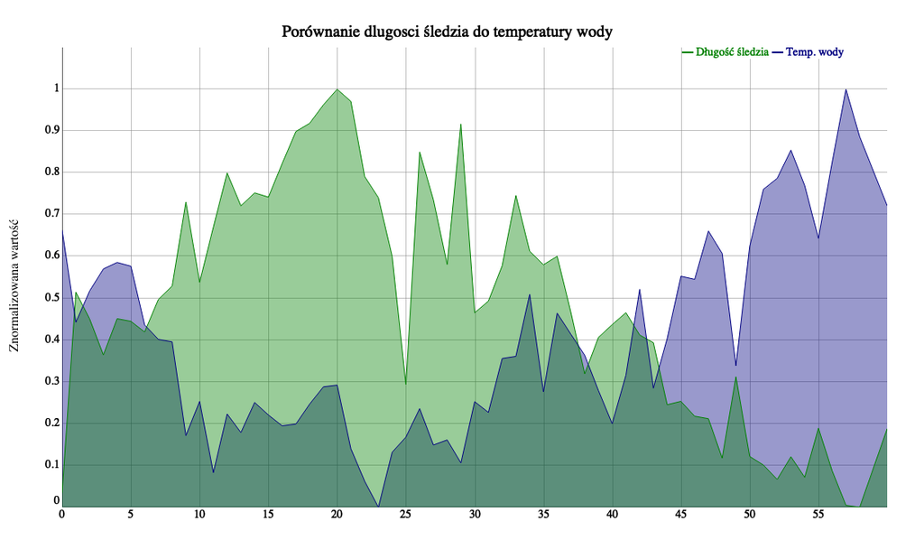

```r
saveWidget(p2, "temp.html", selfcontained = FALSE)
webshot("temp.html", file = names[2],
        cliprect = c(10,30,width+50,height+50)
        ,vwidth = width, vheight = height )
```

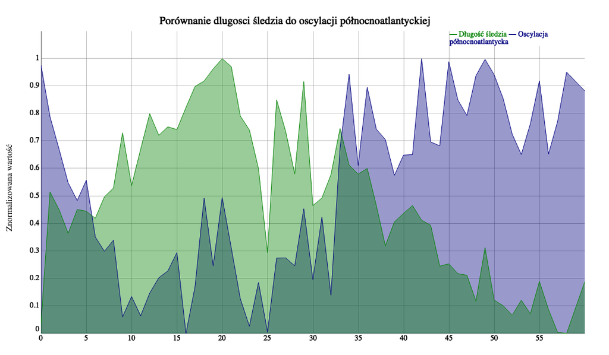